# “Seek and impute” - GPS-datan imputaatio

Pyry Toivonen

2024-04-28

Palaa portfolion aloitussivulle

Koodin konteksti: koodi on osa keskeneräistä tutkimusartikkelia, jolle ei ole vielä käsikirjoitusta eikä lopullisia analyysejä tehty. Koodi on osa aineiston valmistelua analyysejä varten. Koodi toimii esimerkkinä GPS-datan imputaatiosta eläinten dispersaalin mallintamista varten.

Koodi koostuu kahdesta osasta: dispersoivien supikoirien etsiminen (seek) ja imputointi (impute)

Aineisto koostuu yli 30:sta dispersoivasta supikoirasta, jotka Riistakeskus on pannoittanut Lapissa. Imputaatio toteutetaan sovittamalla aineistoon Continous-Time Correlated Random Walk (CRWT) -malli, jonka avulla ennustetaan puuttuvat paikannukset.

Koodin annotaatio sisältää sekaisin suomea ja englantia. Koodia ei ole kaikilta osin annotoitu.

Koodin on tehnyt kokonaan Pyry Toivonen.

```r
## Packages
library(dplyr)
library(tidyverse)
library(lubridate)
library(sf)
library(amt)
```

Koodi, jolla tuodaan R:ään jokainen Lapin supikoira.

```r
# Creating a vector working as a list of folder paths including all the raccoon dogs from different years
pathlist <- c("2011"="2011/CSV tiedostot",
              "2012"="2012/CSV tiedostot",
              "2013"="2013/CSV tiedostot",
              "2014"="2014/CSV tiedostot",
              "2015"="2015/CSV tiedostot",
              "2016"="2016/CSV tiedostot",
              "2017"="2017/CSV tiedostot",
              "2018-2022"="2018-2022/CSV tiedostot")

unname(pathlist)
```

```
## [1] "2011/CSV tiedostot"      "2012/CSV tiedostot"
## [3] "2013/CSV tiedostot"      "2014/CSV tiedostot"
## [5] "2015/CSV tiedostot"      "2016/CSV tiedostot"
## [7] "2017/CSV tiedostot"      "2018-2022/CSV tiedostot"
```

```r
names(pathlist)
```

```
## [1] "2011"      "2012"      "2013"      "2014"      "2015"      "2016"
## [7] "2017"      "2018-2022"
```

```r
RaccList <- list()
IndividualList <- list()

### Importing all the raccoon dog files (folder path changes for each loop)
for (j in 1:length(pathlist)) {

  supilist <-list.files(path = unname(pathlist[j]), pattern=".csv", full.names = TRUE)

  IDVec <- 1:length(supilist)

  Individuals <- data.frame(Name = supilist,
                            ID = IDVec,
                            Year = names(pathlist[j]))

  IndividualList[[j]] <- Individuals


  supi.list <- list() # Empty list

  ## filling list with dataframes
  for (i in 1:length(supilist)) {

    supi.list[[i]] <- read.csv(supilist[i], sep=";", dec=",")
    supi.list[[i]]$ID <- c(IDVec[i]) # assigning ID
    supi.list[[i]] <- dplyr::select(supi.list[[i]], ID, Name, Sex, EventDate, Latitude, Longitude, Month)
  }


  ## Merging all the imported raccoon dog files to one data.frame
  DF_supit <- do.call(rbind, supi.list)

  DF_supit$Latitude <- as.numeric(DF_supit$Latitude)
  DF_supit$Longitude <- as.numeric(DF_supit$Longitude)

  ## Cleaning up the data
  DF_supit <- DF_supit %>%
    filter(!is.na(Latitude)) %>%
    filter(!is.na(Name)) %>%
    filter(Longitude > 1)


  # Changing the date column to the same date format that can be read by R. Original dates were in three different formats.
  DF_supit$EventDate <- parse_date_time(DF_supit$EventDate, orders = c("%m/%d/%Y %H:%M", "%Y-%m-%d %H:%M", "%Y-%m-%d %H:%M:%S"))

  # Removing duplicated rows
  DF_supit <- DF_supit[!duplicated(DF_supit[,c("EventDate","ID")]),]

  DF_supit$StudyYear <- names(pathlist[j])

  RaccList[[names(pathlist[j])]] <- DF_supit
}


# Creating nested data.frame
RaccList <- lapply(RaccList, function(df) {
  df %>%
    nest(.by=ID)
})
```

Muutetaan aineisto AMT-objekteiksi, jotta voidaan tehdä resamplaus ja valikoida dispersoivat tai vaeltavat supikoirat kaikkien supikoirien joukosta.

```r
### Data preparation as AMT-object
## Converting data to AMT track-object and transforming the coordinates at the same time


for (i in 1:length(RaccList)) {
  RaccList[[i]] <- RaccList[[i]] %>%
    mutate(trk = lapply(data, function(d) {
      make_track(d, .x = Longitude, .y = Latitude, .t = EventDate,
                 crs = st_crs(4326)) %>%
        amt::transform_coords(st_crs(3067))
    }))

}

RaccList[["2011"]] %>% mutate(sr = lapply(trk, summarize_sampling_rate)) %>%
  dplyr::select(ID, sr) %>% unnest
```

```
## # A tibble: 5 × 10
##      ID    min    q1 median   mean     q3   max    sd     n unit
##   <int>  <dbl> <dbl>  <dbl>  <dbl>  <dbl> <dbl> <dbl> <int> <chr>
## 1     1  0.167  2.98      3   7.86   5.98   192  22.5   233 hour
## 2     2 10     10        10  97.0  180     6841 290.    772 min
## 3     3  9     10        11 172.   180     5220 404.   1641 min
## 4     4  9     10        11 124.   180     5219 208.   1268 min
## 5     5  9     10        10  98.5  179     4320 222.    809 min
```

```r
# Resample each burst (individual) to one point per day for plotting.

for (i in 1:length(RaccList)) {
  RaccList[[i]] <- RaccList[[i]] %>%
    mutate(Resampled = lapply(trk, function(x) {
      x %>% track_resample(rate=days(1), tolerance=hours(4))
    }))

}



### Plotting the individuals for inspection by eye and NSD statistics

# Converting AMT-object to SF-objects and adding some columns

for (j in 1:length(RaccList)) {

Resampled_points <- list()
Resampled_lines <- list()

for (i in 1:length(RaccList[[j]][["ID"]])) {

  Resampled_points[[i]] <- as_sf_points(RaccList[[j]][["Resampled"]][[i]][,1:3])
  Resampled_points[[i]]$ID <- as.character(i)
  Resampled_lines[[i]] <- as_sf_lines(RaccList[[j]][["Resampled"]][[i]][,1:3])
  Resampled_lines[[i]]$ID <- as.character(i)
  Resampled_points[[i]]$NSD <- sqrt(as.vector(st_distance(Resampled_points[[i]])[,1]))
  }

RaccList[[j]]$Resampled_points <- Resampled_points
RaccList[[j]]$Resampled_lines <- Resampled_lines

}


## Plotting
library(ggplot2)
library(cowplot)
```

```
## [1] "Plotting NSD graphs"
```

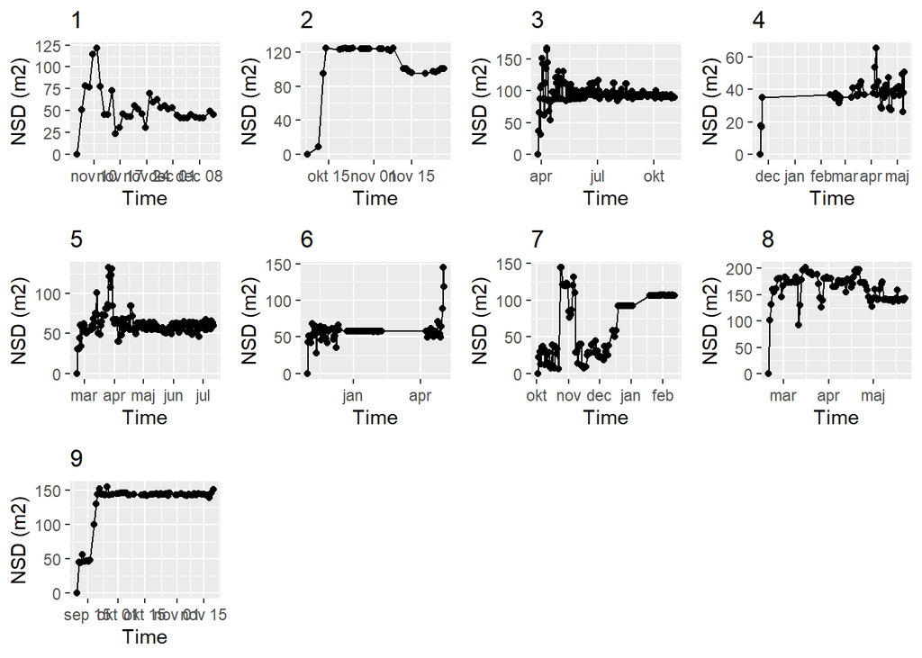

```r
# Tehdään funktio, jolla lasketaan vuosittaiset kuvat
plot.RaccList <- function(Year, option, no_col) {

  if (option == "Simple") {
    # Code to execute for option 1
    print("Plotting simple resampled trajectories")

    plot_list <- list()

    for (i in 1:length(RaccList[[Year]][["ID"]])) {

      plot_list[[i]] <- ggplot() +
        geom_sf(data=RaccList[[Year]][["Resampled_lines"]][[i]]) +
        geom_sf(data=RaccList[[Year]][["Resampled_points"]][[i]]) +
        ggtitle(RaccList[[Year]][["Resampled_lines"]][[i]]$ID)


    }

    plot_grid(plotlist=plot_list, ncol=no_col)

  } else if (option == "NSD traj") {

    print("Plotting resampled trajectories with NSD")

    plot_list <- list()

    for (i in 1:length(RaccList[[Year]][["ID"]])) {

      plot_list[[i]] <- ggplot() +
        geom_sf(data=RaccList[[Year]][["Resampled_lines"]][[i]]) +
        geom_sf(data=RaccList[[Year]][["Resampled_points"]][[i]], aes(col=NSD)) +
        ggtitle(RaccList[[Year]][["Resampled_lines"]][[i]]$ID)


    }

    plot_grid(plotlist=plot_list, ncol=no_col)


  } else if (option == "NSD graph") {

    print("Plotting NSD graphs")

    plot_list <- list()

    for (i in 1:length(RaccList[[Year]][["ID"]])) {
    plot_list[[i]] <- ggplot(data=RaccList[[Year]][["Resampled_points"]][[i]], aes(x=t_, y=NSD)) +
      geom_line() +
      geom_point() +
      ggtitle(RaccList[[Year]][["Resampled_points"]][[i]]$ID) +
      xlab("Time") +
      ylab("NSD (m2)")

    }

    plot_grid(plotlist=plot_list, ncol=no_col)

  } else {
    # Code to handle invalid option
    stop("Invalid option. Please choose 'Simple', 'NSD traj', or 'NSD graph'.")
  }


}


# funktiolla voi valita vuoden, ja kuvatyylin (Simple, NSD traj tai NSD graph). no_col määrää, kuinka monta kolumnia tulee kuvaan
plot.RaccList("2014", "NSD graph", 4)
```